# Yelp Review Classifier

We will use the [Yelp Review Data Set from Kaggle](https://www.kaggle.com/c/yelp-recsys-2013).

Each observation in this dataset is a review of a particular business by a particular user.

The "stars" column is the number of stars (1 through 5) assigned by the reviewer to the business. (Higher stars is better.) In other words, it is the rating of the business by the person who wrote the review.

The "cool" column is the number of "cool" votes this review received from other Yelp users.

All reviews start with 0 "cool" votes, and there is no limit to how many "cool" votes a review can receive. In other words, it is a rating of the review itself, not a rating of the business.

The "useful" and "funny" columns are similar to the "cool" column.

## Data And Setup

```python
import matplotlib.pyplot as plt
import seaborn as sns
import numpy as np
import pandas as pd
import warnings

warnings.filterwarnings('ignore')
plt.rcParams["patch.force_edgecolor"] = True
sns.set(style='whitegrid')
%matplotlib inline
```

```python
yelp_data = pd.read_csv('yelp.csv')
yelp_data.info()
```

```
<class 'pandas.core.frame.DataFrame'>
RangeIndex: 10000 entries, 0 to 9999
Data columns (total 10 columns):
business_id    10000 non-null object
date           10000 non-null object
review_id      10000 non-null object
stars          10000 non-null int64
text           10000 non-null object
type           10000 non-null object
user_id        10000 non-null object
cool           10000 non-null int64
useful         10000 non-null int64
funny          10000 non-null int64
dtypes: int64(4), object(6)
memory usage: 781.3+ KB
```

```python
yelp_data.describe()
```

|  | stars | cool | useful | funny |
| --- | --- | --- | --- | --- |
| count | 10000.000000 | 10000.000000 | 10000.000000 | 10000.000000 |
| mean | 3.777500 | 0.876800 | 1.409300 | 0.701300 |
| std | 1.214636 | 2.067861 | 2.336647 | 1.907942 |
| min | 1.000000 | 0.000000 | 0.000000 | 0.000000 |
| 25% | 3.000000 | 0.000000 | 0.000000 | 0.000000 |
| 50% | 4.000000 | 0.000000 | 1.000000 | 0.000000 |
| 75% | 5.000000 | 1.000000 | 2.000000 | 1.000000 |
| max | 5.000000 | 77.000000 | 76.000000 | 57.000000 |

```python
yelp_data.head(5)
```

|  | business_id | date | review_id | stars | text | type | user_id | cool | useful | funny |
| --- | --- | --- | --- | --- | --- | --- | --- | --- | --- | --- |
| 0 | 9yKzy9PApeiPPOUJEtnvkg | 2011-01-26 | fWKvX83p0-ka4JS3dc6E5A | 5 | My wife took me here on my birthday for breakf... | review | rLtl8ZkDX5vH5nAx9C3q5Q | 2 | 5 | 0 |
| 1 | ZRJwVLyzEJq1VAihDhYiow | 2011-07-27 | IjZ33sJrzXqU-0X6U8NwyA | 5 | I have no idea why some people give bad review... | review | 0a2KyEL0d3Yb1V6aivbIuQ | 0 | 0 | 0 |
| 2 | 6oRAC4uyJCsJl1X0WZpVSA | 2012-06-14 | IESLBzqUCLdSzSqm0eCSxQ | 4 | love the gyro plate. Rice is so good and I als... | review | 0hT2KtfLiobPvh6cDC8JQg | 0 | 1 | 0 |
| 3 | _1QQZuf4zZOyFCvXc0o6Vg | 2010-05-27 | G-WvGaISbqqaMHlNnByodA | 5 | Rosie, Dakota, and I LOVE Chaparral Dog Park!!... | review | uZetl9T0NcROGOyFfughhg | 1 | 2 | 0 |
| 4 | 6ozycU1RpktNG2-1BroVtw | 2012-01-05 | 1uJFq2r5QfJG_6ExMRCaGw | 5 | General Manager Scott Petello is a good egg!!!... | review | vYmM4KTsC8ZfQBg-j5MWkw | 0 | 0 | 0 |

```python
def categorize_review(val):
    result = ''
    if val < 3:
        result = 'Bad'
    elif val == 3:
        result = 'Average'
    else:
        result = 'Good'

    return result

yelp_data['review_category'] = yelp_data['stars'].apply(categorize_review)
yelp_data['text_length'] = yelp_data['text'].apply(len)
yelp_data.head(2)
```

[output not shown]

# EDA

Let's explore the data

**Lets create a countplot of the number of occurrences for each type of star rating.**

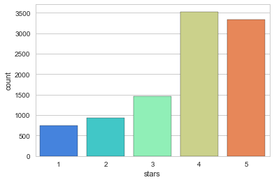

```python
sns.countplot(yelp_data['stars'], palette='rainbow')
```

**Lets use FacetGrid from the seaborn library to create a grid of 5 histograms of text length based off of the star ratings.**

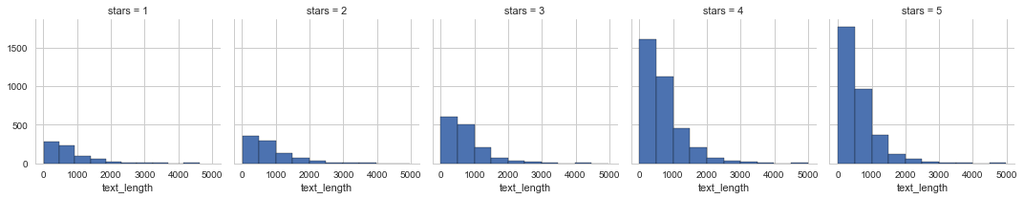

```python
g = sns.FacetGrid(data=yelp_data, col='stars')
g.map(plt.hist, 'text_length')
```

**The above distributions show that text_length of higher ratings like that of four and five have more number of reviews with smaller lengths when compared to other ratings**

## NLP Classification

```python
from sklearn.feature_extraction.text import CountVectorizer, TfidfVectorizer
from sklearn.metrics import confusion_matrix, classification_report
from sklearn.model_selection import train_test_split
from sklearn.naive_bayes import MultinomialNB
from sklearn.pipeline import make_pipeline
```

```python
#yelp_data = yelp_data[(yelp_data.stars==1) | (yelp_data.stars==5)]
x = yelp_data['text']
y = yelp_data['review_category']
x_train, x_test, y_train, y_test = train_test_split(x, y, test_size=0.3, random_state=101)

print('Number Of Data Points In Training Set: ',len(x_train))
print('Number Of Data Points In Testing Set: ',len(x_test))
```

```
Number Of Data Points In Training Set:  7000
Number Of Data Points In Testing Set:  3000
```

**Let's implement CountVectorizer to extract features from text.**

```python
vectorizer = CountVectorizer(stop_words='english')
x_train_transformed = vectorizer.fit_transform(x_train)

print('Total Number Of Features: ', len(vectorizer.get_feature_names()))
```

```
Total Number Of Features:  24213
```

## Let's Training a Model

```python
model = MultinomialNB()
model.fit(x_train_transformed, y_train)
```

```
MultinomialNB(alpha=1.0, class_prior=None, fit_prior=True)
```

## Predictions and Evaluations

Time to see how our model did!

```python
x_test_transformed = vectorizer.transform(x_test)
pred = model.predict(x_test_transformed)
```

**Let's create a confusion matrix and classification report using these predictions and y_test**

```python
print(confusion_matrix(y_test, pred))
```

```
[[  31   53  359]
 [  20  261  212]
 [  24   63 1977]]
```

```python
print(classification_report(y_test, pred))
```

```
             precision    recall  f1-score   support

    Average       0.41      0.07      0.12       443
        Bad       0.69      0.53      0.60       493
       Good       0.78      0.96      0.86      2064

avg / total       0.71      0.76      0.71      3000
```

## Using the Pipeline

**Lets use the pipeline to elminate all the pre processing steps**

```python
pipe_model = make_pipeline(CountVectorizer(stop_words='english'), MultinomialNB())
pipe_model.fit(x_train, y_train)
```

```
Pipeline(steps=[('countvectorizer', CountVectorizer(analyzer='word', binary=False, decode_error='strict',
        dtype=<class 'numpy.int64'>, encoding='utf-8', input='content',
        lowercase=True, max_df=1.0, max_features=None, min_df=1,
        ngram_range=(1, 1), preprocessor=None, stop_words='english',
        strip_accents=None, token_pattern='(?u)\\b\\w\\w+\\b',
        tokenizer=None, vocabulary=None)), ('multinomialnb', MultinomialNB(alpha=1.0, class_prior=None, fit_prior=True))])
```

### Predictions and Evaluation

```python
pred = pipe_model.predict(x_test)
```

```python
print(confusion_matrix(y_test, pred))
print('\n')
print(classification_report(y_test, pred))
```

```
[[  31   53  359]
 [  20  261  212]
 [  24   63 1977]]


             precision    recall  f1-score   support

    Average       0.41      0.07      0.12       443
        Bad       0.69      0.53      0.60       493
       Good       0.78      0.96      0.86      2064

avg / total       0.71      0.76      0.71      3000
```